# Process Simulation Results Solve for Discrete Optimal Allocation YJM

# Optimal Allocation Y, J and M

Y, J and M based optimal allocation.

## Process Simulation Outputs

### Variable Names and Paths

```r
# File Path
srt_simu_path <- 'C:/Users/fan/Documents/Dropbox (UH-ECON)/PrjNygaardSorensenWang/Output/'
# File Name
snm_simu_csv <- 'snwx_v_planner_small.csv'
# Column Names
ar_svr_csv <- c('age', 'marital', 'kids', 'checks', 'ymin', 'ymax', 'mass', 'survive', 'vtilde', 'ctilde')
# Variables That Identify Individual Types
ar_svr_groups <- c('marital', 'kids', 'ymin', 'ymax')
ar_svr_groups_stats <- c('mass', 'survive')
# Number of Checks and Planner Value
svr_checks <- 'checks'
svr_v_value <- 'vtilde'
svr_c_value <- 'ctilde'
```

### Read Input CSV Data

```r
mt_plan_v_tilde <- read.csv(paste0(srt_simu_path, snm_simu_csv), header=FALSE)
df_plan_v_tilde <- as_tibble(mt_plan_v_tilde) %>%
  rename_all(~c(ar_svr_csv)) %>%
  rowid_to_column(var = "id") %>%
  filter(vtilde != 0)

# Column 1: Age (in year before COVID)
# Column 2: Marital status (0 if not married; 1 if married)
# Column 3: Nr of kids (0, 1, ..., 5) where 5 means 5 or more
# Column 4: Number of welfare checks (here either equal to 0 or 1)
# Column 5 and column 6 give income range
# So the individual's income is at least as large as the value in column 5 but strictly less than the value in column 6
# Column 7: Population weight Of that particular group (in the stationary distribution)
# Column 8: Survival probability of that particular age (since the planner knows that some of the individuals will die before next period, so wasn't sure how you wanted me to include that. I did not already include it in V^tilde)
# Column 9: Value of planner as in the slides (with the exception that I didn't multiply by the survival probability
```

```r
REconTools::ff_summ_percentiles(df_plan_v_tilde)
```

[output not shown]

| stats | age | checks | ctilde | id | kids | marital | mass | survive | vtilde | ymax | ymin |
| --- | --- | --- | --- | --- | --- | --- | --- | --- | --- | --- | --- |
| n | 191046 | 191046 | 191046 | 191046 | 191046 | 191046 | 191046 | 191046 | 191046 | 191046 | 191046 |
| unique | 17 | 51 | 187515 | 191046 | 3 | 2 | 3703 | 17 | 189533 | 1 | 158 |
| NAobs | 0 | 0 | 0 | 0 | 0 | 0 | 0 | 0 | 0 | 0 | 0 |
| ZEROobs | 0 | 3746 | 0 | 0 | 64515 | 99348 | 0 | 0 | 0 | 0 | 0 |
| mean | 2.597784e+01 | 2.500000e+01 | 1.661324e+00 | 9.552350e+04 | 9.946610e-01 | 4.799786e-01 | 2.667869e-04 | 2.008267e+00 | -1.099456e+00 | 1.000000e+31 | 1.317829e+05 |
| sd | 3.568692e+00 | 1.471964e+01 | 9.789679e-01 | 5.515037e+04 | 8.185494e-01 | 4.996003e-01 | 7.341167e-04 | 5.933304e-01 | 2.599145e+00 | 0.000000e+00 | 7.236255e+04 |
| cv | 0.1373744 | 0.5887856 | 0.5892699 | 0.5773488 | 0.8229431 | 1.0408803 | 2.7516969 | 0.2954441 | -2.3640278 | 0.0000000 | 0.5491044 |
| min | 1.800000e+01 | 0.000000e+00 | 2.170736e-01 | 1.000000e+00 | 0.000000e+00 | 0.000000e+00 | 1.395051e-49 | -5.772157e-01 | -1.755908e+01 | 1.000000e+31 | 2.438352e+04 |
| p01 | 1.800000e+01 | 0.000000e+00 | 3.021847e-01 | 1.911450e+03 | 0.000000e+00 | 0.000000e+00 | 5.006923e-35 | -5.772157e-01 | -9.741661e+00 | 1.000000e+31 | 3.454332e+04 |
| p05 | 2.000000e+01 | 2.000000e+00 | 4.901908e-01 | 9.553250e+03 | 0.000000e+00 | 0.000000e+00 | 1.908171e-20 | 9.227843e-01 | -6.340533e+00 | 1.000000e+31 | 4.063920e+04 |

[output cut: 8 more lines]

### Aggregate Away Age

Suppose the Planner does not observe Age. (Within group utilitarian, across group Rawlsian):

```r
dim(df_plan_v_tilde)
```

```
[1] 191046     11
```

```r
df_plan_v_tilde_yjm <- df_plan_v_tilde %>%
  mutate(vtilde_m = vtilde*mass, ctilde_m = ctilde*mass) %>%
  arrange(marital, kids, checks, ymin, ymax, age, vtilde) %>%
  group_by(marital, kids, checks, ymin, ymax) %>%
  summarize(vtilde = mean(vtilde_m)/sum(mass),
            ctilde = mean(ctilde_m)/sum(mass),
            mass = sum(mass),
            survive = mean(survive)) %>%
  ungroup() %>%
  rowid_to_column(var = "id")
dim(df_plan_v_tilde_yjm)
```

```
[1] 41820    10
```

### Generate ID dataframe, and Value dataframe using Group IDs

Split dataframe, so that there is one dataframe with just ID information. And there is another dataframe with ID and associated check, values, and mass. Within each group, there are multiple checks possibly.

```r
# group id
svr_group_id <- 'group_id'
# Define
ls_svr_group_vars <- ar_svr_groups
# panel dataframe following
df_plan_v_tilde_id <- df_plan_v_tilde_yjm %>%
  arrange(!!!syms(ls_svr_group_vars)) %>%
  group_by(!!!syms(ls_svr_group_vars)) %>%
  mutate(!!sym(svr_group_id) := (row_number()==1)*1) %>%
  ungroup() %>%
  mutate(!!sym(svr_group_id) := cumsum(!!sym(svr_group_id))) %>%
  select(one_of(svr_group_id, ls_svr_group_vars), everything())
```

Stats Check:

```r
# Stats
# REconTools::ff_summ_count_unique_by_groups(
#   df_plan_v_tilde_id,ls_svr_group_vars,svr_group_id)
# REconTools::ff_summ_percentiles(df_plan_v_tilde_id, bl_statsasrows = FALSE)
```

ID Identifying Dataframe

```r
# Select Grouping by Variables
df_id <- df_plan_v_tilde_id %>%
  select(one_of(svr_group_id, ls_svr_group_vars, ar_svr_groups_stats)) %>%
  group_by(!!!syms(svr_group_id)) %>%
  slice_head() %>% ungroup() %>%
  select(one_of(svr_group_id, ls_svr_group_vars, ar_svr_groups_stats)) %>%
  rename(id_i = !!sym(svr_group_id))
ar_group_ids <- unique(df_id %>% pull(id_i))
# Summarize
REconTools::ff_summ_percentiles(df_id)
```

```
attributes are not identical across measure variables;
they will be dropped
```

| stats | id.i | kids | marital | mass | survive | ymax | ymin |
| --- | --- | --- | --- | --- | --- | --- | --- |
| n | 820 | 820 | 820 | 820 | 820 | 820 | 820 |
| unique | 820 | 3 | 2 | 820 | 327 | 1 | 158 |
| NAobs | 0 | 0 | 0 | 0 | 0 | 0 | 0 |
| ZEROobs | 0 | 273 | 416 | 0 | 0 | 0 | 0 |
| mean | 4.105000e+02 | 1.001220e+00 | 4.926829e-01 | 1.218761e-03 | 2.019183e+00 | 1.000000e+31 | 1.695894e+05 |
| sd | 2.368579e+02 | 8.172430e-01 | 5.002516e-01 | 2.437094e-03 | 3.868989e-01 | 0.000000e+00 | 8.574571e+04 |
| cv | 0.5769985 | 0.8162476 | 1.0153621 | 1.9996496 | 0.1916117 | 0.0000000 | 0.5056078 |
| min | 1.000000e+00 | 0.000000e+00 | 0.000000e+00 | 9.084826e-32 | -5.772157e-01 | 1.000000e+31 | 2.438352e+04 |
| p01 | 9.190000e+00 | 0.000000e+00 | 0.000000e+00 | 2.617637e-28 | -7.721566e-02 | 1.000000e+31 | 2.844744e+04 |
| p05 | 4.195000e+01 | 0.000000e+00 | 0.000000e+00 | 2.178563e-17 | 1.590817e+00 | 1.000000e+31 | 4.063920e+04 |

[output cut: 8 more lines]

Dataframew with ID, check, mass and values

```r
# Select 4 variables
df_value <- df_plan_v_tilde_id %>%
  select(one_of(svr_group_id, svr_checks, svr_v_value, svr_c_value))
# Summarize
REconTools::ff_summ_percentiles(df_value)
```

```
attributes are not identical across measure variables;
they will be dropped
```

| stats | checks | ctilde | group.id | vtilde |
| --- | --- | --- | --- | --- |
| n | 41820 | 41820 | 41820 | 41820 |
| unique | 51 | 41820 | 820 | 41820 |
| NAobs | 0 | 0 | 0 | 0 |
| ZEROobs | 820 | 0 | 0 | 0 |
| mean | 25.00000000 | 0.93796134 | 410.50000000 | 0.03074019 |
| sd | 14.719777 | 1.191901 | 236.716265 | 1.563078 |
| cv | 0.5887911 | 1.2707360 | 0.5766535 | 50.8480132 |
| min | 0.00000000 | 0.03289513 | 1.00000000 | -17.55907505 |
| p01 | 0.00000000 | 0.04751216 | 9.00000000 | -7.44144428 |
| p05 | 2.00000000 | 0.07633419 | 41.95000000 | -0.89915103 |

[output cut: 8 more lines]

```r
# REconTools::ff_summ_count_unique_by_groups(df_value, svr_group_id, svr_group_id)
```

## Generate Dataframe Inputs for the Allocation Problem

Restructure the value dataframe slightly so that it can be used with the allocation functions. Note that the output structure has an *A* column and an *alpha* column, and starts counting *checks* at 1. For the check = 1 row, *A* is the value without the check, and *alpha* is the marginal effects of the checks.

### Generate IL Dataframe Core

```r
# 1. id column and id_il
df_il <- df_value %>% rename(id_i = !!sym(svr_group_id)) %>%
  mutate(id_il = row_number()) %>%
  select(id_i, id_il, everything())
# 2. D_max_i and D_il
df_il <- df_il %>%
  arrange(id_i, svr_checks) %>% group_by(id_i) %>%
  mutate(D_max_i = n()) %>%
  rename(D_il = !!sym(svr_checks)) %>%
  mutate(beta_i = 1/n()) %>%
  select(id_i, id_il, D_max_i, D_il, everything())
# Summarize
REconTools::ff_summ_percentiles(df_il)
```

```
attributes are not identical across measure variables;
they will be dropped
```

| stats | beta.i | ctilde | D.il | D.max.i | id.i | id.il | vtilde |
| --- | --- | --- | --- | --- | --- | --- | --- |
| n | 41820 | 41820 | 41820 | 41820 | 41820 | 41820 | 41820 |
| unique | 1 | 41820 | 51 | 1 | 820 | 41820 | 41820 |
| NAobs | 0 | 0 | 0 | 0 | 0 | 0 | 0 |
| ZEROobs | 0 | 0 | 820 | 0 | 0 | 0 | 0 |
| mean | 1.960784e-02 | 9.379613e-01 | 2.500000e+01 | 5.100000e+01 | 4.105000e+02 | 2.091050e+04 | 3.074019e-02 |
| sd | 0.000000 | 1.191901 | 14.719777 | 0.000000 | 236.716265 | 12072.538465 | 1.563078 |
| cv | 0.0000000 | 1.2707360 | 0.5887911 | 0.0000000 | 0.5766535 | 0.5773434 | 50.8480132 |
| min | 0.01960784 | 0.03289513 | 0.00000000 | 51.00000000 | 1.00000000 | 1.00000000 | -17.55907505 |
| p01 | 0.01960784 | 0.04751216 | 0.00000000 | 51.00000000 | 9.00000000 | 419.19000000 | -7.44144428 |
| p05 | 0.01960784 | 0.07633419 | 2.00000000 | 51.00000000 | 41.95000000 | 2091.95000000 | -0.89915103 |

[output cut: 8 more lines]

### Generate IL Dataframe for Utility

Generate A and alpha:

```r
# 3. A_il and alpha_il
df_il_U <- df_il %>%
  mutate(c_alpha_il = lead(!!sym(svr_c_value)) - (!!sym(svr_c_value)),
         v_alpha_il = lead(!!sym(svr_v_value)) - (!!sym(svr_v_value))) %>%
  rename(c_A_il = !!sym(svr_c_value),
         v_A_il = !!sym(svr_v_value)) %>%
  ungroup()

# 4. drop max check
df_il_U <- df_il_U %>%
  filter(D_il != max(df_il$D_il)) %>%
  mutate(D_il = D_il + 1)
```

Summarize:

```r
# https://fanwangecon.github.io/PrjOptiAlloc/reference/df_opt_caschool_input_il.html
# id_i id_il D_max_i  D_il  A_il alpha_il  beta_i
head(df_il_U, 50)
```

| id_i | id_il | D_max_i | D_il | v_A_il | c_A_il | beta_i | c_alpha_il | v_alpha_il |
| --- | --- | --- | --- | --- | --- | --- | --- | --- |
| 1 | 1 | 51 | 1 | -10.381750 | 0.2803800 | 0.01960784 | 0.001721885 | 0.02411716 |
| 1 | 2 | 51 | 2 | -10.357633 | 0.2821019 | 0.01960784 | 0.001721885 | 0.02411716 |
| 1 | 3 | 51 | 3 | -10.333515 | 0.2838238 | 0.01960784 | 0.001721885 | 0.02411716 |
| 1 | 4 | 51 | 4 | -10.309398 | 0.2855457 | 0.01960784 | 0.001721885 | 0.02411716 |
| 1 | 5 | 51 | 5 | -10.285281 | 0.2872676 | 0.01960784 | 0.001721885 | 0.02411716 |
| 1 | 6 | 51 | 6 | -10.261164 | 0.2889894 | 0.01960784 | 0.001721885 | 0.02411716 |
| 1 | 7 | 51 | 7 | -10.237047 | 0.2907113 | 0.01960784 | 0.001654930 | 0.02223905 |
| 1 | 8 | 51 | 8 | -10.214808 | 0.2923663 | 0.01960784 | 0.001512714 | 0.01817667 |
| 1 | 9 | 51 | 9 | -10.196631 | 0.2938790 | 0.01960784 | 0.001513921 | 0.01819276 |
| 1 | 10 | 51 | 10 | -10.178438 | 0.2953929 | 0.01960784 | 0.001512848 | 0.01817846 |

[output cut: 40 more lines]

```r
tail(df_il_U, 50)
```

| id_i | id_il | D_max_i | D_il | v_A_il | c_A_il | beta_i | c_alpha_il | v_alpha_il |
| --- | --- | --- | --- | --- | --- | --- | --- | --- |
| 820 | 41770 | 51 | 1 | 1.810469 | 4.805444 | 0.01960784 | 0.0005013291 | 0.0001087462 |
| 820 | 41771 | 51 | 2 | 1.810578 | 4.805945 | 0.01960784 | 0.0005013291 | 0.0001087462 |
| 820 | 41772 | 51 | 3 | 1.810687 | 4.806446 | 0.01960784 | 0.0005013291 | 0.0001087462 |
| 820 | 41773 | 51 | 4 | 1.810796 | 4.806948 | 0.01960784 | 0.0005013291 | 0.0001087462 |
| 820 | 41774 | 51 | 5 | 1.810904 | 4.807449 | 0.01960784 | 0.0005013291 | 0.0001087462 |
| 820 | 41775 | 51 | 6 | 1.811013 | 4.807950 | 0.01960784 | 0.0005013291 | 0.0001087462 |
| 820 | 41776 | 51 | 7 | 1.811122 | 4.808452 | 0.01960784 | 0.0005013291 | 0.0001087462 |
| 820 | 41777 | 51 | 8 | 1.811231 | 4.808953 | 0.01960784 | 0.0005013291 | 0.0001087462 |
| 820 | 41778 | 51 | 9 | 1.811339 | 4.809454 | 0.01960784 | 0.0005013291 | 0.0001087462 |
| 820 | 41779 | 51 | 10 | 1.811448 | 4.809956 | 0.01960784 | 0.0005013291 | 0.0001087462 |

[output cut: 40 more lines]

```r
# Summarize
REconTools::ff_summ_percentiles(df_il_U)
```

```
attributes are not identical across measure variables;
they will be dropped
```

| stats | beta.i | c.A.il | c.alpha.il | D.il | D.max.i | id.i | id.il | v.A.il | v.alpha.il |
| --- | --- | --- | --- | --- | --- | --- | --- | --- | --- |
| n | 41000 | 41000 | 41000 | 41000 | 41000 | 41000 | 41000 | 41000 | 41000 |
| unique | 1 | 41000 | 26993 | 50 | 1 | 820 | 41000 | 41000 | 27425 |
| NAobs | 0 | 0 | 0 | 0 | 0 | 0 | 0 | 0 | 0 |
| ZEROobs | 0 | 0 | 0 | 0 | 0 | 0 | 0 | 0 | 0 |
| mean | 1.960784e-02 | 9.378589e-01 | 2.059372e-04 | 2.550000e+01 | 5.100000e+01 | 4.105000e+02 | 2.091000e+04 | 3.045166e-02 | 5.865786e-04 |
| sd | 0.000000e+00 | 1.191846e+00 | 2.104456e-04 | 1.443105e+01 | 0.000000e+00 | 2.367163e+02 | 1.207254e+04 | 1.563991e+00 | 2.138031e-03 |
| cv | 0.0000000 | 1.2708157 | 1.0218920 | 0.5659234 | 0.0000000 | 0.5766536 | 0.5773573 | 51.3598100 | 3.6449179 |
| min | 1.960784e-02 | 3.289513e-02 | 1.461094e-05 | 1.000000e+00 | 5.100000e+01 | 1.000000e+00 | 1.000000e+00 | -1.755908e+01 | 3.669814e-05 |
| p01 | 1.960784e-02 | 4.748784e-02 | 3.441535e-05 | 1.000000e+00 | 5.100000e+01 | 9.000000e+00 | 4.189900e+02 | -7.447702e+00 | 5.620906e-05 |
| p05 | 1.960784e-02 | 7.624448e-02 | 4.968752e-05 | 3.000000e+00 | 5.100000e+01 | 4.195000e+01 | 2.091900e+03 | -8.999590e-01 | 7.565306e-05 |

[output cut: 8 more lines]

#### Rescale Dataframe

Utility could be negative, inequality usually considered over positive outcomes. We can rescale utility to be positive. The extreme Rawlsian only cares about relative $A$ and the utilitarian only cares about $\alpha$, so in some sense, shifting the utility levels up do not really matter. In principle inequality of Utils makes sense but there is no clear scale. Hence inequality over consumption, income other other types of outcomes with hard-scales could be easier to interpret.

```r
# Rescale
df_il_U <- df_il_U %>%
  mutate(v_A_il = v_A_il + 18) %>%
  mutate(v_A_il = case_when(v_A_il >= 1 ~ v_A_il,
                            v_A_il <  1 ~ 1 ))
# Summarize
REconTools::ff_summ_percentiles(df_il_U)
```

```
attributes are not identical across measure variables;
they will be dropped
```

| stats | beta.i | c.A.il | c.alpha.il | D.il | D.max.i | id.i | id.il | v.A.il | v.alpha.il |
| --- | --- | --- | --- | --- | --- | --- | --- | --- | --- |
| n | 41000 | 41000 | 41000 | 41000 | 41000 | 41000 | 41000 | 41000 | 41000 |
| unique | 1 | 41000 | 26993 | 50 | 1 | 820 | 41000 | 40984 | 27425 |
| NAobs | 0 | 0 | 0 | 0 | 0 | 0 | 0 | 0 | 0 |
| ZEROobs | 0 | 0 | 0 | 0 | 0 | 0 | 0 | 0 | 0 |
| mean | 1.960784e-02 | 9.378589e-01 | 2.059372e-04 | 2.550000e+01 | 5.100000e+01 | 4.105000e+02 | 2.091000e+04 | 1.803056e+01 | 5.865786e-04 |
| sd | 0.000000e+00 | 1.191846e+00 | 2.104456e-04 | 1.443105e+01 | 0.000000e+00 | 2.367163e+02 | 1.207254e+04 | 1.562749e+00 | 2.138031e-03 |
| cv | 0.00000000 | 1.27081574 | 1.02189200 | 0.56592336 | 0.00000000 | 0.57665364 | 0.57735729 | 0.08667222 | 3.64491795 |
| min | 1.960784e-02 | 3.289513e-02 | 1.461094e-05 | 1.000000e+00 | 5.100000e+01 | 1.000000e+00 | 1.000000e+00 | 1.000000e+00 | 3.669814e-05 |
| p01 | 1.960784e-02 | 4.748784e-02 | 3.441535e-05 | 1.000000e+00 | 5.100000e+01 | 9.000000e+00 | 4.189900e+02 | 1.055230e+01 | 5.620906e-05 |
| p05 | 1.960784e-02 | 7.624448e-02 | 4.968752e-05 | 3.000000e+00 | 5.100000e+01 | 4.195000e+01 | 2.091900e+03 | 1.710004e+01 | 7.565306e-05 |

[output cut: 8 more lines]

## Preference Vector

Preference vectors:

```r
ar_rho <- 1 - (10^(c(seq(-2,2, length.out=8))))
ar_rho <- unique(ar_rho)
```

## Select Random Subset

select data subset:

```r
# subset select
set.seed(123)
it_draw <- 820
ar_group_rand <- ar_group_ids[sample(length(ar_group_ids), it_draw, replace=FALSE)]
df_input_il <- df_il_U %>%
  filter(id_i %in% ar_group_rand) %>%
  mutate(id_il = row_number())
```

## Generate Alternative Allocations

Suppose we allocate Uniformly across individuals

```r
# checks - 1 because will have alpha + A, A = 11, alpha = adding 1 check given 11 checks
it_avg_check <- 12
# 2020 consumption
df_input_ib_c <- df_input_il %>%
  filter(D_il == it_avg_check-1) %>%
  rename(A_i_l0 = c_A_il) %>%
  rename(alpha_o_i = c_alpha_il) %>%
  select(id_i, A_i_l0, alpha_o_i, beta_i)
# value
df_input_ib_v <- df_input_il %>%
  filter(D_il == it_avg_check-1) %>%
  rename(A_i_l0 = v_A_il) %>%
  rename(alpha_o_i = v_alpha_il) %>%
  select(id_i, A_i_l0, alpha_o_i, beta_i)
# summarize
REconTools::ff_summ_percentiles(df_input_ib_c)
```

```
attributes are not identical across measure variables;
they will be dropped
```

| stats | A.i.l0 | alpha.o.i | beta.i | id.i |
| --- | --- | --- | --- | --- |
| n | 820 | 820 | 820 | 820 |
| unique | 820 | 820 | 1 | 820 |
| NAobs | 0 | 0 | 0 | 0 |
| ZEROobs | 0 | 0 | 0 | 0 |
| mean | 9.348914e-01 | 2.049545e-04 | 1.960784e-02 | 4.105000e+02 |
| sd | 1.190946e+00 | 2.093628e-04 | 0.000000e+00 | 2.368579e+02 |
| cv | 1.2738870 | 1.0215087 | 0.0000000 | 0.5769985 |
| min | 0.033669273 | 0.000014611 | 0.019607843 | 1.000000000 |
| p01 | 4.578831e-02 | 3.487217e-05 | 1.960784e-02 | 9.190000e+00 |
| p05 | 7.469444e-02 | 4.933631e-05 | 1.960784e-02 | 4.195000e+01 |

[output cut: 8 more lines]

```r
REconTools::ff_summ_percentiles(df_input_ib_v)
```

```
attributes are not identical across measure variables;
they will be dropped
```

| stats | A.i.l0 | alpha.o.i | beta.i | id.i |
| --- | --- | --- | --- | --- |
| n | 820 | 820 | 820 | 820 |
| unique | 820 | 820 | 1 | 820 |
| NAobs | 0 | 0 | 0 | 0 |
| ZEROobs | 0 | 0 | 0 | 0 |
| mean | 1.802236e+01 | 5.777279e-04 | 1.960784e-02 | 4.105000e+02 |
| sd | 1.588791e+00 | 2.070531e-03 | 0.000000e+00 | 2.368579e+02 |
| cv | 0.08815666 | 3.58392040 | 0.00000000 | 0.57699855 |
| min | 1.000000e+00 | 3.669814e-05 | 1.960784e-02 | 1.000000e+00 |
| p01 | 1.049578e+01 | 5.637033e-05 | 1.960784e-02 | 9.190000e+00 |
| p05 | 1.708824e+01 | 7.565301e-05 | 1.960784e-02 | 4.195000e+01 |

[output cut: 8 more lines]

## Allocate for All

First Allocation based on 2020 Consumption:

```r
# Inputs
# 30 individuals 25 checks, half the amount is available
fl_dis_w <- dim(df_input_ib_c)[1]*it_avg_check
df_input_il_c <- df_input_il %>%
  rename(A_il = c_A_il) %>%
  rename(alpha_il = c_alpha_il) %>%
  select(-v_A_il, -v_alpha_il)

# Solve with Function
ls_dis_solu_c <- suppressWarnings(suppressMessages(
  ffp_opt_anlyz_rhgin_dis(ar_rho,
                          fl_dis_w,
                          df_input_il_c,
                          bl_df_alloc_il = FALSE,
                          bl_return_V = TRUE,
                          bl_return_allQ_V = FALSE,
                          bl_return_inner_V = FALSE)))
```

```
|===============================================================================================================================================|100% ~0 s remaining
```

```r
df_queue_il_long_c <-ls_dis_solu_c$df_queue_il_long
df_alloc_i_long_c <- ls_dis_solu_c$df_alloc_i_long
df_rho_gini_c <- ls_dis_solu_c$df_rho_gini
```

Second Allocation based on life-time utility:

```r
# Inputs
# 30 individuals 25 checks, half the amount is available
fl_dis_w <- dim(df_input_ib_v)[1]*it_avg_check
df_input_il_v <- df_input_il %>%
  rename(A_il = v_A_il) %>%
  rename(alpha_il = v_alpha_il) %>%
  select(-c_A_il, -c_alpha_il)

# Solve with Function
ls_dis_solu_v <- suppressWarnings(suppressMessages(
  ffp_opt_anlyz_rhgin_dis(ar_rho,
                          fl_dis_w,
                          df_input_il_v,
                          bl_df_alloc_il = FALSE,
                          bl_return_V = TRUE,
                          bl_return_allQ_V = FALSE,
                          bl_return_inner_V = FALSE)))
```

```
|===============================================================================================================================================|100% ~0 s remaining
```

```r
df_queue_il_long_v <-ls_dis_solu_v$df_queue_il_long
df_alloc_i_long_v <- ls_dis_solu_v$df_alloc_i_long
df_rho_gini_v <- ls_dis_solu_v$df_rho_gini
```

## Welfare Comparison Optimal vs Unifom Allocation

```r
REconTools::ff_summ_percentiles(df_queue_il_long_c, bl_statsasrows = FALSE)
```

```
attributes are not identical across measure variables;
they will be dropped
```

| var | n | unique | NAobs | ZEROobs | mean | sd | cv | min | p01 | p05 | p10 | p25 | p50 | p75 | p90 | p95 | p99 | max |
| --- | --- | --- | --- | --- | --- | --- | --- | --- | --- | --- | --- | --- | --- | --- | --- | --- | --- | --- |
| D.il | 328000 | 50 | 0 | 0 | 25.50000 | 1.443089e+01 | 0.5659173 | 1.00000000 | 1.00000000 | 3.00000000 | 5.90000000 | 13.0000000 | 25.5000000 | 3.800000e+01 | 45.1000 | 48.0000 | 50.0000 | 50.0000 |
| D.max.i | 328000 | 1 | 0 | 0 | 51.00000 | 0.000000e+00 | 0.0000000 | 51.00000000 | 51.00000000 | 51.00000000 | 51.00000000 | 51.0000000 | 51.0000000 | 5.100000e+01 | 51.0000 | 51.0000 | 51.0000 | 51.0000 |
| D.Wbin.il | 328000 | 2 | 0 | 249280 | 0.24000 | 4.270838e-01 | 1.7795158 | 0.00000000 | 0.00000000 | 0.00000000 | 0.00000000 | 0.0000000 | 0.0000000 | 0.000000e+00 | 1.0000 | 1.0000 | 1.0000 | 1.0000 |
| id.i | 328000 | 820 | 0 | 0 | 410.50000 | 2.367138e+02 | 0.5766475 | 1.00000000 | 9.00000000 | 41.95000000 | 82.90000000 | 205.7500000 | 410.5000000 | 6.152500e+02 | 738.1000 | 779.0500 | 812.0000 | 820.0000 |
| id.il | 328000 | 41000 | 0 | 0 | 20500.50000 | 1.183570e+04 | 0.5773371 | 1.00000000 | 410.99000000 | 2050.95000000 | 4100.90000000 | 10250.7500000 | 20500.5000000 | 3.075025e+04 | 36900.1000 | 38950.0500 | 40590.0100 | 41000.0000 |
| Q.il | 328000 | 41000 | 0 | 0 | 20500.50000 | 1.183570e+04 | 0.5773371 | 1.00000000 | 410.99000000 | 2050.95000000 | 4100.90000000 | 10250.7500000 | 20500.5000000 | 3.075025e+04 | 36900.1000 | 38950.0500 | 40590.0100 | 41000.0000 |
| rho | 328000 | 8 | 0 | 0 | 4.50000 | 2.291291e+00 | 0.5091759 | 1.00000000 | 1.00000000 | 1.00000000 | 1.00000000 | 2.7500000 | 4.5000000 | 6.250000e+00 | 8.0000 | 8.0000 | 8.0000 | 8.0000 |
| rho.val | 328000 | 8 | 0 | 0 | -16.08234 | 3.248283e+01 | -2.0197830 | -99.00000000 | -99.00000000 | -99.00000000 | -99.00000000 | -11.1043820 | -0.2243226 | 8.864689e-01 | 0.9900 | 0.9900 | 0.9900 | 0.9900 |
| V.star.Q.il | 328000 | 64791 | 249280 | NA | 32.87236 | 6.728211e+01 | 2.0467683 | 0.01277309 | 0.01295495 | 0.01322274 | 0.01334077 | 0.0373007 | 7.6905093 | 1.768567e+01 | 209.0575 | 209.7359 | 210.0635 | 210.1347 |

```r
REconTools::ff_summ_percentiles(df_alloc_i_long_c, bl_statsasrows = FALSE)
```

```
attributes are not identical across measure variables;
they will be dropped
```

| var | n | unique | NAobs | ZEROobs | mean | sd | cv | min | p01 | p05 | p10 | p25 | p50 | p75 | p90 | p95 | p99 | max |
| --- | --- | --- | --- | --- | --- | --- | --- | --- | --- | --- | --- | --- | --- | --- | --- | --- | --- | --- |
| D.max.i | 6560 | 1 | 0 | 0 | 51.0000000 | 0.0000000 | 0.0000000 | 51.00000000 | 51.00000000 | 51.00000000 | 51.0000000 | 51.0000000 | 51.0000000 | 51.0000000 | 51.0000000 | 51.0000000 | 51.0000000 | 51.0000000 |
| D.star.i | 6560 | 34 | 0 | 4892 | 12.0000000 | 21.1922713 | 1.7660226 | 0.00000000 | 0.00000000 | 0.00000000 | 0.0000000 | 0.0000000 | 0.0000000 | 6.0000000 | 50.0000000 | 50.0000000 | 50.0000000 | 50.0000000 |
| EH.star.i | 6560 | 1314 | 0 | 0 | 0.9364349 | 1.1910991 | 1.2719508 | 0.03289513 | 0.04744167 | 0.07780609 | 0.1026199 | 0.1872243 | 0.4048734 | 1.1086515 | 2.8883709 | 3.9758785 | 4.8305101 | 5.4108200 |
| F.star.i | 6560 | 34 | 0 | 4892 | 0.2352941 | 0.4155347 | 1.7660226 | 0.00000000 | 0.00000000 | 0.00000000 | 0.0000000 | 0.0000000 | 0.0000000 | 0.1176471 | 0.9803922 | 0.9803922 | 0.9803922 | 0.9803922 |
| id.i | 6560 | 820 | 0 | 0 | 410.5000000 | 236.7314786 | 0.5766906 | 1.00000000 | 9.00000000 | 41.95000000 | 82.9000000 | 205.7500000 | 410.5000000 | 615.2500000 | 738.1000000 | 779.0500000 | 812.0000000 | 820.0000000 |
| rho | 6560 | 8 | 0 | 0 | 4.5000000 | 2.2914625 | 0.5092139 | 1.00000000 | 1.00000000 | 1.00000000 | 1.0000000 | 2.7500000 | 4.5000000 | 6.2500000 | 8.0000000 | 8.0000000 | 8.0000000 | 8.0000000 |
| rho.val | 6560 | 8 | 0 | 0 | -16.0823357 | 32.4852553 | -2.0199339 | -99.00000000 | -99.00000000 | -99.00000000 | -99.0000000 | -11.1043820 | -0.2243226 | 0.8864689 | 0.9900000 | 0.9900000 | 0.9900000 | 0.9900000 |

```r
REconTools::ff_summ_percentiles(df_queue_il_long_v, bl_statsasrows = FALSE)
```

```
attributes are not identical across measure variables;
they will be dropped
```

| var | n | unique | NAobs | ZEROobs | mean | sd | cv | min | p01 | p05 | p10 | p25 | p50 | p75 | p90 | p95 | p99 | max |
| --- | --- | --- | --- | --- | --- | --- | --- | --- | --- | --- | --- | --- | --- | --- | --- | --- | --- | --- |
| D.il | 328304 | 50 | 0 | 0 | 25.4841367 | 1.443442e+01 | 0.5664078 | 1.0000000 | 1.0000000 | 3.0000000 | 5.0000000 | 13.000000 | 25.0000000 | 3.800000e+01 | 45.000 | 48.000 | 50.000 | 50.000 |
| D.max.i | 328304 | 1 | 0 | 0 | 51.0000000 | 0.000000e+00 | 0.0000000 | 51.0000000 | 51.0000000 | 51.0000000 | 51.0000000 | 51.000000 | 51.0000000 | 5.100000e+01 | 51.000 | 51.000 | 51.000 | 51.000 |
| D.Wbin.il | 328304 | 2 | 0 | 249280 | 0.2407037 | 4.275114e-01 | 1.7760896 | 0.0000000 | 0.0000000 | 0.0000000 | 0.0000000 | 0.000000 | 0.0000000 | 0.000000e+00 | 1.000 | 1.000 | 1.000 | 1.000 |
| id.i | 328304 | 820 | 0 | 0 | 410.3773088 | 2.366385e+02 | 0.5766364 | 1.0000000 | 9.0000000 | 42.0000000 | 83.0000000 | 206.000000 | 410.0000000 | 6.150000e+02 | 738.000 | 779.000 | 812.000 | 820.000 |
| id.il | 328304 | 41000 | 0 | 0 | 20494.3495784 | 1.183194e+04 | 0.5773271 | 1.0000000 | 411.0000000 | 2052.1500000 | 4104.0000000 | 10260.000000 | 20481.5000000 | 3.074100e+04 | 36897.000 | 38948.850 | 40590.000 | 41000.000 |
| Q.il | 328304 | 40996 | 0 | 0 | 20481.5228325 | 1.184663e+04 | 0.5784057 | 1.0000000 | 373.0000000 | 2014.1500000 | 4066.0000000 | 10222.000000 | 20481.5000000 | 3.074100e+04 | 36897.000 | 38948.850 | 40590.000 | 41000.000 |
| rho | 328304 | 8 | 0 | 0 | 4.5000000 | 2.291291e+00 | 0.5091759 | 1.0000000 | 1.0000000 | 1.0000000 | 1.0000000 | 2.750000 | 4.5000000 | 6.250000e+00 | 8.000 | 8.000 | 8.000 | 8.000 |
| rho.val | 328304 | 8 | 0 | 0 | -16.0823357 | 3.248283e+01 | -2.0197830 | -99.0000000 | -99.0000000 | -99.0000000 | -99.0000000 | -11.104382 | -0.2243226 | 8.864689e-01 | 0.990 | 0.990 | 0.990 | 0.990 |
| V.star.Q.il | 328304 | 59216 | 249280 | NA | 850.1218450 | 1.847505e+03 | 2.1732237 | 0.8796926 | 0.8926566 | 0.8929841 | 0.8931335 | 2.063184 | 150.8121588 | 3.554479e+02 | 5716.756 | 5718.041 | 5718.668 | 5718.798 |

```r
REconTools::ff_summ_percentiles(df_alloc_i_long_v, bl_statsasrows = FALSE)
```

```
attributes are not identical across measure variables;
they will be dropped
```

| var | n | unique | NAobs | ZEROobs | mean | sd | cv | min | p01 | p05 | p10 | p25 | p50 | p75 | p90 | p95 | p99 | max |
| --- | --- | --- | --- | --- | --- | --- | --- | --- | --- | --- | --- | --- | --- | --- | --- | --- | --- | --- |
| D.max.i | 6560 | 1 | 0 | 0 | 51.0000000 | 0.0000000 | 0.00000000 | 51.000000 | 51.0000 | 51.00000 | 51.00000 | 51.00000 | 51.0000000 | 51.0000000 | 51.0000000 | 51.0000000 | 51.0000000 | 51.0000000 |
| D.star.i | 6560 | 21 | 0 | 4943 | 12.0000000 | 21.2854048 | 1.77378373 | 0.000000 | 0.0000 | 0.00000 | 0.00000 | 0.00000 | 0.0000000 | 0.0000000 | 50.0000000 | 50.0000000 | 50.0000000 | 50.0000000 |
| EH.star.i | 6560 | 916 | 0 | 0 | 18.0382598 | 1.5154309 | 0.08401203 | 1.982849 | 10.8232 | 17.13329 | 17.40731 | 17.72444 | 18.0405920 | 18.4873415 | 19.4737088 | 19.8079897 | 20.2168879 | 20.5164694 |
| F.star.i | 6560 | 21 | 0 | 4943 | 0.2352941 | 0.4173609 | 1.77378373 | 0.000000 | 0.0000 | 0.00000 | 0.00000 | 0.00000 | 0.0000000 | 0.0000000 | 0.9803922 | 0.9803922 | 0.9803922 | 0.9803922 |
| id.i | 6560 | 820 | 0 | 0 | 410.5000000 | 236.7314786 | 0.57669057 | 1.000000 | 9.0000 | 41.95000 | 82.90000 | 205.75000 | 410.5000000 | 615.2500000 | 738.1000000 | 779.0500000 | 812.0000000 | 820.0000000 |
| rho | 6560 | 8 | 0 | 0 | 4.5000000 | 2.2914625 | 0.50921389 | 1.000000 | 1.0000 | 1.00000 | 1.00000 | 2.75000 | 4.5000000 | 6.2500000 | 8.0000000 | 8.0000000 | 8.0000000 | 8.0000000 |
| rho.val | 6560 | 8 | 0 | 0 | -16.0823357 | 32.4852553 | -2.01993392 | -99.000000 | -99.0000 | -99.00000 | -99.00000 | -11.10438 | -0.2243226 | 0.8864689 | 0.9900000 | 0.9900000 | 0.9900000 | 0.9900000 |

2020 Consumption comparison:

```r
tb_rho_rev_c <-
  PrjOptiAlloc::ffp_opt_anlyz_sodis_rev(ar_rho,
                          fl_dis_w,
                          df_input_ib = df_input_ib_c,
                          df_queue_il_long_with_V = df_queue_il_long_c)
```

```
`cols` is now required when using unnest().
Please use `cols = c(rev)`
```

```r
# Display Results
print(tb_rho_rev_c)
```

| rho | rho_val | REV |
| --- | --- | --- |
| 1 | 0.9900000 | 0.7538618 |
| 2 | 0.9627241 | 0.7643293 |
| 3 | 0.8610505 | 0.7584350 |
| 4 | 0.4820525 | 0.8148374 |
| 5 | -0.9306977 | 0.9283537 |
| 6 | -6.1968567 | 0.9898374 |
| 7 | -25.8269580 | 0.9962398 |
| 8 | -99.0000000 | 0.9978659 |

Life-time Value comparison:

```r
tb_rho_rev_v <-
  PrjOptiAlloc::ffp_opt_anlyz_sodis_rev(ar_rho,
                          fl_dis_w,
                          df_input_ib = df_input_ib_v,
                          df_queue_il_long_with_V = df_queue_il_long_v)
```

```
`cols` is now required when using unnest().
Please use `cols = c(rev)`
```

```r
# Display Results
print(tb_rho_rev_v)
```

| rho | rho_val | REV |
| --- | --- | --- |
| 1 | 0.9900000 | 0.9739837 |
| 2 | 0.9627241 | 0.9782520 |
| 3 | 0.8610505 | 0.9794715 |
| 4 | 0.4820525 | 0.9895325 |
| 5 | -0.9306977 | 0.9976626 |
| 6 | -6.1968567 | 0.9998984 |
| 7 | -25.8269580 | 0.9998984 |
| 8 | -99.0000000 | 0.9998984 |

### Welfare Comparison Figure

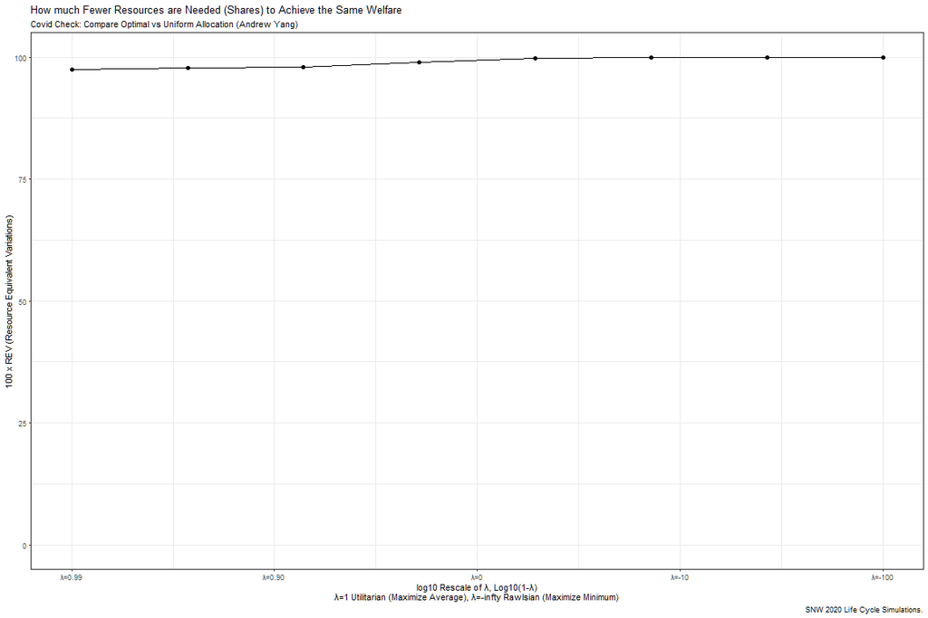

```r
# x-labels
x.labels <- c('λ=0.99', 'λ=0.90', 'λ=0', 'λ=-10', 'λ=-100')
x.breaks <- c(0.01, 0.10, 1, 10, 100)

# title line 2
# title_line1 <- sprintf("Percentage of Training Spots Misallocated, NSW Lalonde (AER, 1986)")
# title_line2 <- sprintf("REV (Resource Equivalent Variation) Along Planner Spectrum")

st_title <- sprintf(paste0('How much Fewer Resources are Needed (Shares) to Achieve the Same Welfare'))
title_line1 <- sprintf("Covid Check: Compare Optimal vs Uniform Allocation (Andrew Yang)")

# Graph Results--Draw
line.plot <- tb_rho_rev_v %>%
  mutate(REV = 100*REV)  %>%
  mutate(one_minus_rho = 1 - rho_val)  %>%
  ggplot(aes(x=one_minus_rho, y=REV)) +
  geom_line() +
  geom_point() +
  # geom_vline(xintercept=c(1), linetype="dotted") +
  labs(title = st_title,
       subtitle = paste0(title_line1),
       x = 'log10 Rescale of λ, Log10(1-λ)\nλ=1 Utilitarian (Maximize Average), λ=-infty Rawlsian (Maximize Minimum)',
       y = paste0('100 x REV (Resource Equivalent Variations)'),
       caption = 'SNW 2020 Life Cycle Simulations.') +
  scale_x_continuous(trans='log10', labels = x.labels, breaks = x.breaks) +
  theme_bw(base_size=8) +
  ylim(0, 100)
# +
#   guides(colour=FALSE)


# Print
print(line.plot)
```

```r
spt_img_save <- 'img/'
bl_save_img <- FALSE
if (bl_save_img) {
  snm_cnts <- 'opti_vs_unif_rev.png'
  png(paste0(spt_img_save, snm_cnts),
      width = 135, height = 96, units='mm', res = 300, pointsize=7)
  print(line.plot)
  dev.off()
}
```

## Allocation Results Analysis

Join the allocation level dataframe with individual attributes:

```r
# Summarize
df_alloc_i_long_covar_v <- df_alloc_i_long_v %>% left_join(df_id, by = "id_i")
df_alloc_i_long_covar_c <- df_alloc_i_long_c %>% left_join(df_id, by = "id_i")
```

### C Allocation Amounts by Attributes

Summarize check level statistics by key attributes:

```r
ls_svr_groups <- c('ymin', 'marital', 'kids')
for (svr_group in ls_svr_groups) {

  # Group by variable
  print(paste0('current group = ', svr_group))

  # Summarize
  df <- df_alloc_i_long_covar_c
  vars.group <- c('rho_val', svr_group)
  var.numeric <- 'D_star_i'
  str.stats.group <- 'allperc'
  ar.perc <- c(0.10, 0.5, 0.90)
  ls_summ_by_group <- REconTools::ff_summ_bygroup(
    df, vars.group, var.numeric, str.stats.group, ar.perc)
  print(ls_summ_by_group$df_table_grp_stats)

}
```

```
[1] "current group = ymin"
```

```
attributes are not identical across measure variables;
they will be dropped
```

| rho.val | ymin | mean | median | sd | IQR | mad | 10% | 50% | 90% | min | max | first | last | n.distinct |
| --- | --- | --- | --- | --- | --- | --- | --- | --- | --- | --- | --- | --- | --- | --- |
| -99.0000000 | 24383.52 | 0.0000000 | 0.0 | 0.000000 | 0.00 | 0.0000 | 0.0 | 0.0 | 0.0 | 0 | 0 | 0 | 0 | 1 |
| -99.0000000 | 26415.48 | 7.7500000 | 0.0 | 15.500000 | 7.75 | 0.0000 | 0.0 | 0.0 | 21.7 | 0 | 31 | 0 | 31 | 2 |
| -99.0000000 | 28447.44 | 5.1666667 | 0.0 | 12.655697 | 0.00 | 0.0000 | 0.0 | 0.0 | 15.5 | 0 | 31 | 0 | 31 | 2 |
| -99.0000000 | 30479.40 | 10.2500000 | 3.5 | 16.173538 | 13.75 | 5.1891 | 0.0 | 3.5 | 25.9 | 0 | 34 | 0 | 34 | 3 |
| -99.0000000 | 32511.36 | 1.5000000 | 1.5 | 2.121320 | 1.50 | 2.2239 | 0.3 | 1.5 | 2.7 | 0 | 3 | 0 | 3 | 2 |
| -99.0000000 | 34543.32 | 50.0000000 | 50.0 | 0.000000 | 0.00 | 0.0000 | 50.0 | 50.0 | 50.0 | 50 | 50 | 50 | 50 | 1 |
| -99.0000000 | 36575.28 | 50.0000000 | 50.0 | 0.000000 | 0.00 | 0.0000 | 50.0 | 50.0 | 50.0 | 50 | 50 | 50 | 50 | 1 |
| -99.0000000 | 38607.24 | 50.0000000 | 50.0 | 0.000000 | 0.00 | 0.0000 | 50.0 | 50.0 | 50.0 | 50 | 50 | 50 | 50 | 1 |
| -99.0000000 | 40639.20 | 50.0000000 | 50.0 | 0.000000 | 0.00 | 0.0000 | 50.0 | 50.0 | 50.0 | 50 | 50 | 50 | 50 | 1 |
| -99.0000000 | 42671.16 | 50.0000000 | 50.0 | 0.000000 | 0.00 | 0.0000 | 50.0 | 50.0 | 50.0 | 50 | 50 | 50 | 50 | 1 |

[output cut: 990 more lines]

```
[1] "current group = marital"
```

```
attributes are not identical across measure variables;
they will be dropped
```

| rho.val | marital | mean | median | sd | IQR | mad | 10% | 50% | 90% | min | max | first | last | n.distinct |
| --- | --- | --- | --- | --- | --- | --- | --- | --- | --- | --- | --- | --- | --- | --- |
| -99.0000000 | 0 | 14.403846 | 0 | 22.47098 | 50.0 | 0 | 0 | 0 | 50 | 0 | 50 | 0 | 50 | 10 |
| -99.0000000 | 1 | 9.524752 | 0 | 19.58267 | 0.0 | 0 | 0 | 0 | 50 | 0 | 50 | 0 | 50 | 5 |
| -25.8269580 | 0 | 14.336538 | 0 | 22.42314 | 50.0 | 0 | 0 | 0 | 50 | 0 | 50 | 0 | 50 | 10 |
| -25.8269580 | 1 | 9.594059 | 0 | 19.59563 | 0.0 | 0 | 0 | 0 | 50 | 0 | 50 | 0 | 50 | 7 |
| -6.1968567 | 0 | 14.355769 | 0 | 22.58784 | 50.0 | 0 | 0 | 0 | 50 | 0 | 50 | 0 | 50 | 6 |
| -6.1968567 | 1 | 9.574257 | 0 | 19.58571 | 0.0 | 0 | 0 | 0 | 50 | 0 | 50 | 0 | 50 | 7 |
| -0.9306977 | 0 | 13.283654 | 0 | 22.00616 | 50.0 | 0 | 0 | 0 | 50 | 0 | 50 | 0 | 50 | 9 |
| -0.9306977 | 1 | 10.678218 | 0 | 20.29021 | 0.0 | 0 | 0 | 0 | 50 | 0 | 50 | 0 | 50 | 8 |
| 0.4820525 | 0 | 11.052885 | 0 | 20.49125 | 1.5 | 0 | 0 | 0 | 50 | 0 | 50 | 0 | 50 | 7 |
| 0.4820525 | 1 | 12.975248 | 0 | 21.62664 | 43.0 | 0 | 0 | 0 | 50 | 0 | 50 | 0 | 50 | 9 |

[output cut: 6 more lines]

```
[1] "current group = kids"
```

```
attributes are not identical across measure variables;
they will be dropped
```

| rho.val | kids | mean | median | sd | IQR | mad | 10% | 50% | 90% | min | max | first | last | n.distinct |
| --- | --- | --- | --- | --- | --- | --- | --- | --- | --- | --- | --- | --- | --- | --- |
| -99.0000000 | 0 | 11.644689 | 0 | 21.10570 | 0.00 | 0 | 0 | 0 | 50 | 0 | 50 | 0 | 50 | 4 |
| -99.0000000 | 1 | 12.212454 | 0 | 21.38080 | 3.00 | 0 | 0 | 0 | 50 | 0 | 50 | 0 | 50 | 6 |
| -99.0000000 | 2 | 12.142336 | 0 | 21.26214 | 7.75 | 0 | 0 | 0 | 50 | 0 | 50 | 0 | 50 | 8 |
| -25.8269580 | 0 | 11.714286 | 0 | 21.15591 | 0.00 | 0 | 0 | 0 | 50 | 0 | 50 | 0 | 50 | 5 |
| -25.8269580 | 1 | 12.241758 | 0 | 21.39699 | 6.00 | 0 | 0 | 0 | 50 | 0 | 50 | 0 | 50 | 6 |
| -25.8269580 | 2 | 12.043796 | 0 | 21.11450 | 7.50 | 0 | 0 | 0 | 50 | 0 | 50 | 0 | 50 | 10 |
| -6.1968567 | 0 | 11.578755 | 0 | 21.00250 | 0.00 | 0 | 0 | 0 | 50 | 0 | 50 | 0 | 50 | 6 |
| -6.1968567 | 1 | 12.285714 | 0 | 21.52732 | 0.00 | 0 | 0 | 0 | 50 | 0 | 50 | 0 | 50 | 4 |
| -6.1968567 | 2 | 12.135036 | 0 | 21.38998 | 2.50 | 0 | 0 | 0 | 50 | 0 | 50 | 0 | 50 | 6 |
| -0.9306977 | 0 | 11.435897 | 0 | 20.92381 | 0.00 | 0 | 0 | 0 | 50 | 0 | 50 | 0 | 50 | 5 |

[output cut: 14 more lines]

### V Allocation Amounts by Attributes

Summarize check level statistics by key attributes:

```r
ls_svr_groups <- c('ymin', 'marital', 'kids')
for (svr_group in ls_svr_groups) {

  # Group by variable
  print(paste0('current group = ', svr_group))

  # Summarize
  df <- df_alloc_i_long_covar_v
  vars.group <- c('rho_val', svr_group)
  var.numeric <- 'D_star_i'
  str.stats.group <- 'allperc'
  ar.perc <- c(0.10, 0.5, 0.90)
  ls_summ_by_group <- REconTools::ff_summ_bygroup(
    df, vars.group, var.numeric, str.stats.group, ar.perc)
  print(ls_summ_by_group$df_table_grp_stats)

}
```

```
[1] "current group = ymin"
```

```
attributes are not identical across measure variables;
they will be dropped
```

| rho.val | ymin | mean | median | sd | IQR | mad | 10% | 50% | 90% | min | max | first | last | n.distinct |
| --- | --- | --- | --- | --- | --- | --- | --- | --- | --- | --- | --- | --- | --- | --- |
| -99.0000000 | 24383.52 | 50.000000 | 50.0 | 0.000000 | 0.00 | 0.0000 | 50.0 | 50.0 | 50.0 | 50 | 50 | 50 | 50 | 1 |
| -99.0000000 | 26415.48 | 50.000000 | 50.0 | 0.000000 | 0.00 | 0.0000 | 50.0 | 50.0 | 50.0 | 50 | 50 | 50 | 50 | 1 |
| -99.0000000 | 28447.44 | 50.000000 | 50.0 | 0.000000 | 0.00 | 0.0000 | 50.0 | 50.0 | 50.0 | 50 | 50 | 50 | 50 | 1 |
| -99.0000000 | 30479.40 | 50.000000 | 50.0 | 0.000000 | 0.00 | 0.0000 | 50.0 | 50.0 | 50.0 | 50 | 50 | 50 | 50 | 1 |
| -99.0000000 | 32511.36 | 50.000000 | 50.0 | 0.000000 | 0.00 | 0.0000 | 50.0 | 50.0 | 50.0 | 50 | 50 | 50 | 50 | 1 |
| -99.0000000 | 34543.32 | 50.000000 | 50.0 | 0.000000 | 0.00 | 0.0000 | 50.0 | 50.0 | 50.0 | 50 | 50 | 50 | 50 | 1 |
| -99.0000000 | 36575.28 | 50.000000 | 50.0 | 0.000000 | 0.00 | 0.0000 | 50.0 | 50.0 | 50.0 | 50 | 50 | 50 | 50 | 1 |
| -99.0000000 | 38607.24 | 50.000000 | 50.0 | 0.000000 | 0.00 | 0.0000 | 50.0 | 50.0 | 50.0 | 50 | 50 | 50 | 50 | 1 |
| -99.0000000 | 40639.20 | 50.000000 | 50.0 | 0.000000 | 0.00 | 0.0000 | 50.0 | 50.0 | 50.0 | 50 | 50 | 50 | 50 | 1 |
| -99.0000000 | 42671.16 | 50.000000 | 50.0 | 0.000000 | 0.00 | 0.0000 | 50.0 | 50.0 | 50.0 | 50 | 50 | 50 | 50 | 1 |

[output cut: 990 more lines]

```
[1] "current group = marital"
```

```
attributes are not identical across measure variables;
they will be dropped
```

| rho.val | marital | mean | median | sd | IQR | mad | 10% | 50% | 90% | min | max | first | last | n.distinct |
| --- | --- | --- | --- | --- | --- | --- | --- | --- | --- | --- | --- | --- | --- | --- |
| -99.0000000 | 0 | 12.76923 | 0 | 21.74074 | 47 | 0 | 0 | 0 | 50 | 0 | 50 | 0 | 50 | 6 |
| -99.0000000 | 1 | 11.20792 | 0 | 20.73911 | 0 | 0 | 0 | 0 | 50 | 0 | 50 | 0 | 50 | 9 |
| -25.8269580 | 0 | 13.43269 | 0 | 22.16108 | 50 | 0 | 0 | 0 | 50 | 0 | 50 | 0 | 50 | 4 |
| -25.8269580 | 1 | 10.52475 | 0 | 20.30333 | 0 | 0 | 0 | 0 | 50 | 0 | 50 | 0 | 50 | 7 |
| -6.1968567 | 0 | 13.61298 | 0 | 22.19338 | 50 | 0 | 0 | 0 | 50 | 0 | 50 | 0 | 50 | 6 |
| -6.1968567 | 1 | 10.33911 | 0 | 20.20347 | 0 | 0 | 0 | 0 | 50 | 0 | 50 | 0 | 50 | 4 |
| -0.9306977 | 0 | 13.83654 | 0 | 22.38184 | 50 | 0 | 0 | 0 | 50 | 0 | 50 | 0 | 50 | 3 |
| -0.9306977 | 1 | 10.10891 | 0 | 19.98257 | 0 | 0 | 0 | 0 | 50 | 0 | 50 | 0 | 50 | 7 |
| 0.4820525 | 0 | 13.94712 | 0 | 22.42690 | 50 | 0 | 0 | 0 | 50 | 0 | 50 | 0 | 50 | 4 |
| 0.4820525 | 1 | 9.99505 | 0 | 19.91807 | 0 | 0 | 0 | 0 | 50 | 0 | 50 | 0 | 50 | 4 |

[output cut: 6 more lines]

```
[1] "current group = kids"
```

```
attributes are not identical across measure variables;
they will be dropped
```

| rho.val | kids | mean | median | sd | IQR | mad | 10% | 50% | 90% | min | max | first | last | n.distinct |
| --- | --- | --- | --- | --- | --- | --- | --- | --- | --- | --- | --- | --- | --- | --- |
| -99.0000000 | 0 | 7.380952 | 0 | 17.54704 | 0 | 0 | 0 | 0 | 50 | 0 | 50 | 0 | 50 | 6 |
| -99.0000000 | 1 | 12.278388 | 0 | 21.54449 | 0 | 0 | 0 | 0 | 50 | 0 | 50 | 0 | 50 | 4 |
| -99.0000000 | 2 | 16.324818 | 0 | 23.36336 | 50 | 0 | 0 | 0 | 50 | 0 | 50 | 0 | 50 | 7 |
| -25.8269580 | 0 | 7.692308 | 0 | 18.01839 | 0 | 0 | 0 | 0 | 50 | 0 | 50 | 0 | 50 | 5 |
| -25.8269580 | 1 | 13.146520 | 0 | 22.01121 | 50 | 0 | 0 | 0 | 50 | 0 | 50 | 0 | 50 | 4 |
| -25.8269580 | 2 | 15.149635 | 0 | 22.92198 | 50 | 0 | 0 | 0 | 50 | 0 | 50 | 0 | 50 | 4 |
| -6.1968567 | 0 | 8.241758 | 0 | 18.58566 | 0 | 0 | 0 | 0 | 50 | 0 | 50 | 0 | 50 | 2 |
| -6.1968567 | 1 | 12.794872 | 0 | 21.71392 | 50 | 0 | 0 | 0 | 50 | 0 | 50 | 0 | 50 | 5 |
| -6.1968567 | 2 | 14.952555 | 0 | 22.84527 | 50 | 0 | 0 | 0 | 50 | 0 | 50 | 0 | 50 | 5 |
| -0.9306977 | 0 | 8.241758 | 0 | 18.58566 | 0 | 0 | 0 | 0 | 50 | 0 | 50 | 0 | 50 | 2 |

[output cut: 14 more lines]

### Consumption Based Allocation Figure

Generate the needed dataframe, averaging over ages, averages by ymin, marital status, and kids count:

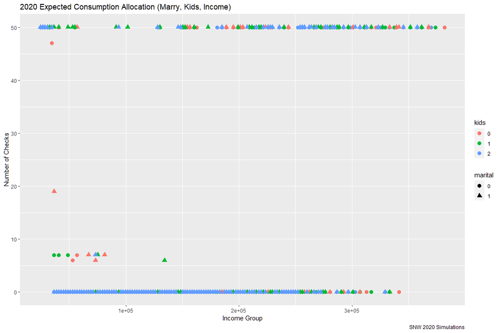

```r
# graph mean check amount by income, marital status and kids counts
lineplot_c <- df_alloc_i_long_covar_c %>%
  filter(rho_val == 0.99) %>% ungroup() %>%
  # filter(marital == 1) %>%
  mutate(kids = as.factor(kids),
         marital = as.factor(marital)) %>%
    ggplot(aes(x=ymin, y=D_star_i ,
               colour=kids,
               shape=marital)) +
        geom_point(size=3) +
        labs(title = '2020 Expected Consumption Allocation (Marry, Kids, Income)',
             x = 'Income Group',
             y = 'Number of Checks',
             caption = 'SNW 2020 Simulations')
print(lineplot_c)
```

### Lifetime Utility Allocation Figure

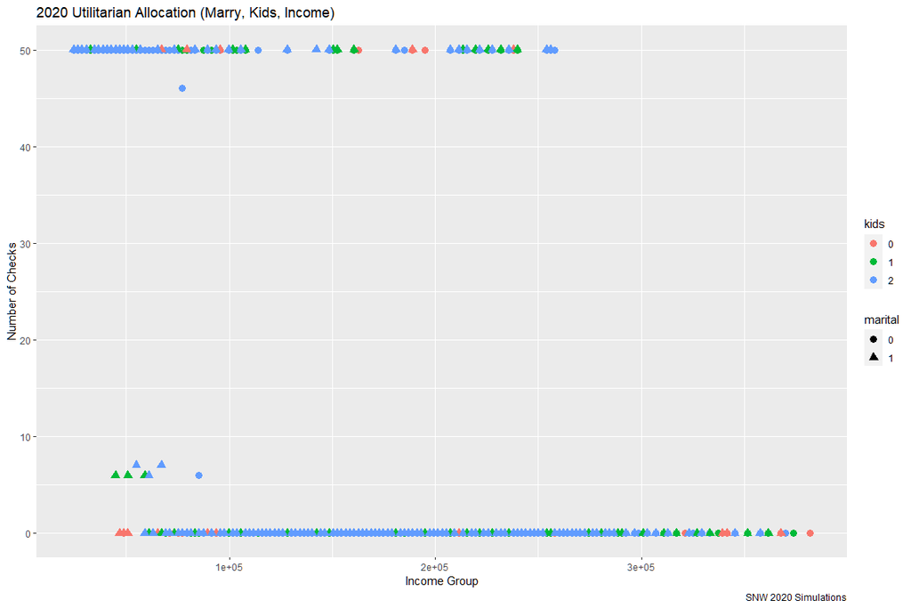

```r
# graph mean check amount by income, marital status and kids counts
lineplot_v <- df_alloc_i_long_covar_v %>%
  filter(rho_val == 0.99) %>% ungroup() %>%
  # filter(marital == 1) %>%
  mutate(kids = as.factor(kids),
         marital = as.factor(marital)) %>%
    ggplot(aes(x=ymin, y=D_star_i ,
               colour=kids,
               shape=marital)) +
        geom_point(size=3) +
        labs(title = '2020 Utilitarian Allocation (Marry, Kids, Income)',
             x = 'Income Group',
             y = 'Number of Checks',
             caption = 'SNW 2020 Simulations')
print(lineplot_v)
```